# Barplots

## Introduction

After importing the QZA files into R and processing them with phyloseq, it’s time to explore the taxonomic composition of our data. We will use the `Polychrome` package to create a custom palette for the barplots. We will build a combined barplot for all hosts.

## Load necessary libraries.

```r
# install.packages(c("tidyverse","ggtext","Polychrome"))
library(tidyverse)
library(Polychrome)
library(ggtext)
```

The taxonomic rank that was used for agglomeration:

```r
agglom.rank<-"Genus"
```

## Specifying parameters and directory/file names.

```r
# cmdargs <- commandArgs(trailingOnly = TRUE)
# active.analysis <- cmdargs[1]
unlockBinding("params", env = .GlobalEnv)
active.analysis <- params$active.analysis
print(paste("The analysis focus is:", active.analysis))
```

```
## [1] "The analysis focus is: all_domains"
```

```r
source(here::here("config/R/config.R"))# config file with global variables
source(here::here("config/R/themes.R"))# config file with themes

## 3. Import datasets. ####
```

## Import datasets.

Import abundance table as an rds file (NOT rarefied):

```r
ps.q.agg<-readRDS(file=file.path(
  community.composition.rdafiles,
  paste("phyloseq-qiime",authorname,agglom.rank,read.end.type,
        truncationlvl,"table.rds",sep = "-")))
custom.md <- readRDS(custom.md.path)
custom.levels<-intersect(names(pretty.level.names),custom.md$class)
```

## Set up the barplot.

First, find where the agglom.rank column is located (what number the `Genus` columns is located at, for example). In case of ASV table, the column is actually called `OTU`.  
We also need to know the location of the preceding taxonomic rank (e.g. `Family`). Usually, it’s to the left of the agglom.rank column.

```r
if(agglom.rank=="OTU"){
  agglom.rank.col<-which(colnames(ps.q.agg) =="Species")
}else{
  agglom.rank.col<-which(colnames(ps.q.agg) ==agglom.rank)
  preceding.rank.col<-which(colnames(ps.q.agg) ==agglom.rank)-1
  preceding.rank<-colnames(ps.q.agg)[preceding.rank.col]
}
custom_order <- c("Kingdom", "Phylum", "Class", "Order", "Family",
                  "Genus","Species")
```

If we agglomerate by higher level (Order, Class, etc), need to adjust the rank by removing the levels below. In case of Order-level data, remove the `Family`, and `Genus`

```r
if(agglom.rank%in%custom_order){
  agglom.rank.index<-match(agglom.rank,custom_order)
  custom_order<-custom_order[1:agglom.rank.index-1]
}
```

### Tidy up the taxonomic names.

First, merge the taxonomic columns into the “taxon” column to find unclassified taxa. If a taxon has “Kingdom”, “Phylum”, “Class”, “Order”, etc. in one of those columns, this taxon is unclassified. These will be left as they are (“taxon” value becomes the agglom.rank), but classified taxa should have the preceding rank in the brackets (agglom.rank and preceding.rank). For example, “Prevotella (Prevotellaceae)” is classified, while “Lachnospiraceae Family” is not. The barplot needs to reflect this. At this point, the “taxon” column is changed. Moreover, if the average relative abundance of a taxon is less than 1%, the “taxon” value becomes “Remainder (mean relative abundance < 1%)” to avoid too many names in the legend.

Unclassified taxa need to be separate from classified ones: we put unclassified ones at the top of the legend. Then, we sort both groups alphabetically.  
Another thing we need to do is wrapping long names using `str_wrap`. We convert the “taxon” column into factor and set the levels as follows: the first level is the “Remainder (mean relative abundance < 1%)” string. Next, unclassified taxa, then classified taxa. We use the str_detect to find unclassified taxa because these have Kingdom or Phylum in the name.

```r
new.df<-ps.q.agg%>%
  unite("taxon",Kingdom:all_of(agglom.rank),sep = ";",remove = FALSE)%>%
  mutate(is_unclassified = grepl
         ("Kingdom|Phylum|Class|Order|Family|Genus|Species",taxon))%>% # add column to show that a taxon was unclassified
  mutate(taxon=ifelse(is_unclassified,
                       get(agglom.rank),
                       paste0(get(agglom.rank), " (",get(preceding.rank),
                              ")")),
         taxon=ifelse(MeanRelativeAbundance<1,"Remainder (mean relative abundance < 1%)",taxon))%>% # if a taxon is classified, we change it to show the preceding rank, e.g Family (Genus)
  group_by_at(c("is_unclassified",preceding.rank))%>%
  arrange(desc(is_unclassified),
          get(preceding.rank),
          taxon,
          .by_group = TRUE)%>% # sort within unclassified and classified taxa (by group)
  ungroup()%>%
  mutate(taxon = gsub("_", " ", taxon),
         taxon = str_wrap(taxon,width=32))%>%
  mutate(taxon=factor(taxon,levels=unique(taxon)),
         taxon=taxon%>%
           fct_relevel(c("Remainder (mean relative\nabundance < 1%)",
                         unique(unlist(lapply(custom_order,
                                              function(pat){levels(.)[str_detect(levels(.),
                                                                                 fixed(pat))]
                                                            })))
                         ),
                       after=0))%>% # change taxon column to factor. Then, we set "Remainder" as the first level, unclassified taxa next, then classified taxa. we use the str_detect to find unclassified taxa because these have Kingdom or Phylum in the name
  ungroup()
```

Create a color palette

```r
set.seed(1)
plot.cols<-createPalette(length(levels(unique(new.df$taxon))),
                         seedcolors =rainbow(7))# input: number of rows

plot.cols<-c("#C1CDCD",plot.cols[1:length(plot.cols)-1])
col.vec<-setNames(plot.cols,levels(new.df$taxon))
```

## Plot the barplot.

We will concatenate the sample name on the x-axis with the number of reads in that sample. It will look like “Sample 1 (n = 25000)”. Actually, this kind of string will be stored in a new column called NewSample.

Then, we will convert the “class” column (host names) into factors that we defined in custom.levels. This will order our bars according to the vector of levels. It must be factor because this allows us ordering custom.levels as we want, otherwise it would be alphabetic. And in our vector, the first level is naked mole-rats. So, the first facet will also be naked mole-rats. Facets are panels that correspond to animal host.

```r
barplot.all<-new.df%>%
  group_by(Sample)%>%
  mutate(TotalAbundance=sum(Abundance))%>% # add total counts per sample,
  # so we can have info about sample size
  ungroup()%>%
  mutate(NewSample=paste0(Sample," (n = ", TotalAbundance, ")"))%>% # add a
  # column where sample names are together with sample sizes
  mutate(class=fct_relevel(class,
                           custom.levels,
                           after = 0))%>%
  # filter(class%in%c("NMR","B6mouse"))%>%
  ggplot(aes(x=NewSample,y=RelativeAbundance,fill=taxon))+
  geom_bar(stat="identity")+
  facet_grid(~class, # separate animal hosts
             scales="free",  # each species will have its own bars inside
             # facet (instead of all bars)
             space = "free",
             labeller = labeller(class=pretty.level.names))+
  theme(legend.position = "bottom")+
  coord_cartesian(expand=FALSE) +
  scale_fill_manual(values = col.vec)+ # custom fill that is based on our
  # custom palette
  xlab("") +
  ylab("Relative Abundance (%)")+
  labs(fill="Taxon",
       caption="Mean Relative Abundance was calculated for each host separately")+
  theme_bw()+
  guides(fill = guide_legend(ncol = 6))+
  # ggtitle(paste(agglom.rank,"level gut microbiota profiles of fecal samples from different rodents"))+
  theme(plot.margin=unit(c(0.1,0.1,0.1,0.5), 'cm'),
        axis.text.y = element_text(size=5), # size of y axis ticks
        axis.title = element_text(size = 7), # size of axis names
        strip.text.x = ggtext::element_markdown(size = 5), # the name of
        # each facet will be recognised as a markdown object, so we can
        # add line breaks (cause host names are too long)
        axis.text.x = element_text(angle=45,size=6,hjust=1),# rotate
        # the x-axis labels by 45 degrees and shift to the right
        plot.caption = element_text(size=5), # size of plot caption
        plot.title = element_text(size = 5), # size of plot title
        panel.grid.minor = element_blank(),
        panel.grid.major = element_blank(),
        legend.title= element_text(size = 7),
        legend.box.spacing = unit(0.1,"lines"), # space between the plot and the legend box
        legend.key.spacing.y = unit(2, "pt"), # distance between the legend's key text
        legend.key.size = unit(0.3, 'cm'), # change legend key size
        legend.text = element_text(margin = margin(l=1), size = 5), # size of the legend text
        legend.position = "bottom" # place the legend under the plot
  )
```

Information about padding and legend size was obtained from: https://stackoverflow.com/a/78067650  
Show the plot:

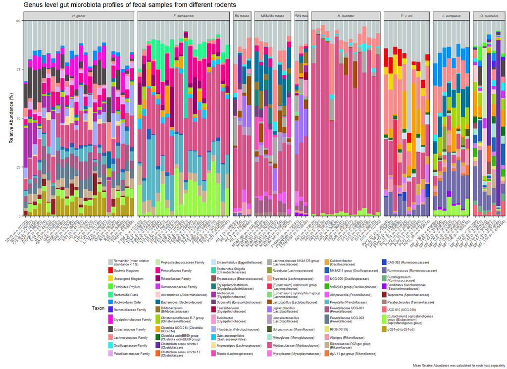

```r
print(barplot.all+
        ggtitle(paste(agglom.rank,"level gut microbiota profiles of fecal samples from different rodents"))+
        theme(plot.title = element_text(size=10))
      )
```

```r
for(image.format in image.formats){
  ggsave(file.path(community.composition.figures,
                paste0(paste("barplot",paste(custom.levels,collapse = '-'),
                      truncationlvl,agglom.rank,
                      sep = "-"),".",image.format)),
         plot=barplot.all,
         width=11, height=8,units="in",
         dpi=800,device = image.format)
}
```

```r
rm(list = ls(all=TRUE))
gc()
```

```
##           used  (Mb) gc trigger  (Mb) max used  (Mb)
## Ncells 3095657 165.4    5832808 311.6  4463472 238.4
## Vcells 5787529  44.2   23211478 177.1 23211275 177.1
```